Abstract Background Dysregulation of RNA guanine-7 methyltransferase (RNMT) plays a crucial role in the tumor progression and immune responses. However, the detailed role of RNMT in pan-cancer is still unknown.

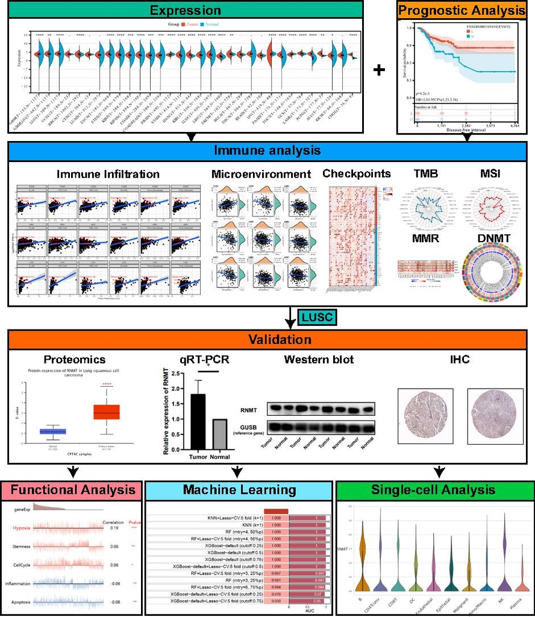

```r
knitr::include_graphics('https://vinnish-1314222618.cos.ap-nanjing.myqcloud.com/20240725_ga.jpg')
```

Methods Bulk transcriptomic data of pan-cancer were obtained from the Cancer Genome Atlas (TCGA), Genotype-Tissue Expression (GTEx), and Cancer Cell Line Encyclopedia (CCLE) databases. Single-cell transcriptomic and proteomics data of lung squamous cell carcinoma (LUSC) were analyzed in the Tumor Immune Single-cell Hub 2 (TISCH2) and Clinical Proteomic Tumor Analysis Consortium (CPTAC) databases, respectively. The correlation between RNMT expression and cancer prognosis was analyzed by Cox proportional hazards regression and Kaplan–Meier analyses. The correlation of RNMT expression with common immunoregulators, tumor mutation burden (TMB), microsatellite instability (MSI), mismatch repair (MMR), and DNA methyltransferase (DNMT) was analyzed. Additionally, the correlation between RNMT expression and immune infiltration level was evaluated. A total of 1287 machine learning combinations were used to construct prognostic models for LUSC. qRT-PCR and Western blot were used to validate the bioinformatics findings of RNMT upregulation in LUSC.

Results RNMT was widely expressed across different cancers, with significant correlation to prognosis in cancers such as kidney chromophobe (KICH) (p = 0.0033, HR = 7.12), liver hepatocellular carcinoma (LIHC) (p = 0.01, HR = 1.41), and others. Notably, RNMT participates in the regulation of the tumor microenvironment. RNMT expression positively correlated with immune cell expression (Spearman’s rank correlation, p < 0.05). Moreover, RNMT expression was strongly associated with immunoregulators, TMB, MSI, MMR, and DNMT in most cancer types. Notably, RNMT expression displayed excellent prognostic and immunological performance in LUSC. The expression of RNMT was mainly enriched in B cells of LUSC tissues. qRT–PCR and Western blot verified the high expression of RNMT in LUSC.

Conclusion RNMT expression widely correlated with prognosis and immune infiltration in various tumors, especially LUSC. The RNMT detection may provide a new idea for future tumor immune studies and treatment strategies.

1. Introduction The prevalence of cancer has become a serious public health concern worldwide, with over 8 million deaths each year. The number of cancer patients will likely continue to increase over the coming decades ( Bray et al., 2013 , Tarver, 2012 ). It is an intimidating and everlasting struggle to fight cancer. As the understanding of cancer diversity ( Hanahan, 2022 ), the identification of powerful tumor markers offers hope for individual-based tumor diagnosis and treatment. Over the last few decades, modern immunotherapy has been regarded as a novel and promising direction for cancer treatment. Considerable progress has been made in immunotherapy, which has revolutionized tumor therapy in many ways. Currently, several immunotherapy strategies, such as monoclonal antibodies, adjuvants, and checkpoint inhibitors are available ( Rusch et al., 2018 ). Immune checkpoints are a collection of inhibitory pathways intrinsic to the immune system. The expression of immune checkpoints is vital for maintaining self-tolerance and preventing autoimmunity ( Pardoll, 2012 ). The rapid development of immune checkpoint blockade has made great help in practical clinical applications. For example, blocking the PD-1 and CTLA-4 pathways markedly increases the survival rate of patients with multiple malignancies, including melanoma, renal cell carcinoma, esophageal squamous cell carcinoma, and non-small cell lung cancer ( Larkin et al., 2019 , Albiges et al., 2020 , Doki et al., 2022 , Hellmann et al., 2019 ). Clinical research on checkpoint inhibitors has become a research hotspot. Nonetheless, challenges still remained, including the translation of pre-clinical findings and the identification of the best therapy for individual patients ( Hegde and Chen, 2020 ). Therefore, more clinical researches on potential and optimal targets need to be conducted in cancer immunotherapy.

N7-methylguanosine (m7G) is an electropositive modification of the mRNA 5′ cap structure, internal mRNA, rRNA, tRNA, miRNA, and lncRNA ( Malbec et al., 2019 , Pandolfini et al., 2019 , Wang et al., 2022 ). m7G modification plays a significant role in mRNA export, metabolism, stability, splicing, and translation ( Zhang et al., 2019 ). Recent research has indicated that changes in m7G affect the development and progression of cancer. Thus, m7G-related genes are considered promising biomarkers for prognosis and treatment ( Luo et al., 2022 ). RNA guanine-7 methyltransferase (RNMT) contains an N-terminal regulatory domain. By regulating RNMT activity and recruitment, N-terminal regulatory domain can transcribe initiation sites ( Aregger and Cowling, 2013 , Glover-Cutter et al., 2008 ). RNMT-mediated modification of m7G methylome plays an important role in RNA translation, the transformation from mammary epithelial cells to fibroblast cells, and T cell activation ( Cowling, 2010 , Galloway et al., 2021 ). Previous studies have demonstrated that abnormal RNMT expression may accelerate the malignant growth of cancer. For example, the hypomethylated promoter of RNMT stimulates the progression of hepatocellular carcinoma tumorigenesis ( Stefanska et al., 2014 ). Inhibition of RNMT induce the death of HeLa cells and breast cancer cells in a PIK3CA mutant background ( Chu and Shatkin, 2008 , Dunn et al., 2019 ). Moreover, down-regulated RNMT expression inhibits the growth of glioma stem-like cells via the B7-H6/c-Myc axis ( Chen et al., 2020 ). Although the function of RNMT in several cancers has been studied, its primary roles in tumor immunity are still unclear. With the rise of bioinformatics, multiple datasets can be used to predict the effects of numerous genes. Here, we obtained datasets from public databases. To evaluate the value of RNMT in pan-cancer, we analyzed survival prognosis, immune status, tumor mutation burden (TMB), microsatellite instability (MSI), mismatch repair (MMR) and DNA methyltransferase (DNMT). Quantitative real-time PCR (qRT–PCR) and Western blot were used to validate the accuracy of our study ( Shuqiang et al., 2022 ).